# Ford GoBike Data Exploration

### by Nick Zwart

## Preliminary Wrangling

This document explores a dataset about individual rides made in a bike-sharing system covering the greater San Francisco Bay area.

### What is the structure of your dataset?

This dataset has 453159 rows and contains 17 columns.

### What is/are the main feature(s) of interest in your dataset?

I want to find out which gender uses this service the most. Finding out how long the average trip takes sounds also interesting to me. I also want to find out when most trips are taken in terms of time of day, day of the week, or month of the year. I also think it might be interesting to find out if subscribers behave differently than customers.

### What features in the dataset do you think will help support your investigation into your feature(s) of interest?

I think the 'member_gender' column will help me to answer my first question. In order to answer the second question I think the 'duration_sec' column will come in handy. For the third question the 'duration_sec', 'start_month' and 'start_day' column will come in handy. The last question can be answered by using the 'duration_sec', 'start_month', 'start_day' and 'user_type' column.

## Univariate Exploration

I'll start looking by which gender uses this service the most.

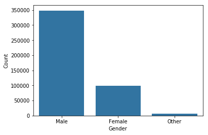

```python
base_color = sb.color_palette()[0]
cat_order = df['member_gender'].value_counts().index
sb.countplot(data = df, x = 'member_gender', color = base_color, order = cat_order)
plt.xlabel('Gender')
plt.ylabel('Count');
```

Interesting, it seems that males use this service way more than females do. Let's continue with the next point. Now I want to know how long the average trip takes.

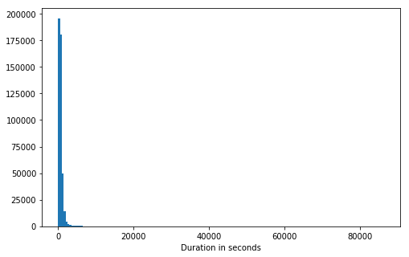

```python
binsize = 500
bins = np.arange(0, df['duration_sec'].max()+binsize, binsize)

plt.figure(figsize=[8, 5])
plt.hist(data = df, x = 'duration_sec', bins = bins)
plt.xlabel('Duration in seconds')
plt.show()
```

There is a long tail in the distribution making the visualization useless. Lets put it on a log scale and see if that imporeves the visualization.

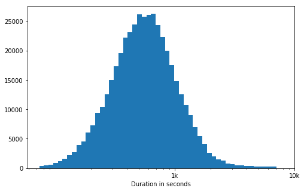

```python
log_binsize = 0.05
bins = 6 ** np.arange(2.4, np.log10(df['duration_sec'].max())+log_binsize, log_binsize)

plt.figure(figsize=[8, 5])
plt.hist(data = df, x = 'duration_sec', bins = bins)
plt.xscale('log')
plt.xticks([10e2, 10e3], ['1k', '10k'])
plt.xlabel('Duration in seconds')
plt.show()
```

If we plot the duration in secondes on a log-scale, we can see that the distribution looks normalilly distributed. The peak is a little below the 1k mark meaning that the mean duration in seconds should somewhere around the 700 - 900 mark. Let's find out what the mean duration in seconds is.

```python
df.duration_sec.mean()
```

```
832.9340143305109
```

### Discuss the distribution(s) of your variable(s) of interest. Were there any unusual points? Did you need to perform any transformations?

The duration_sec column took on a large range of values, so I looked at the data using a log transform. Under the transformation the data looked normally distributed, with the mean around 800 seconds.

### Of the features you investigated, were there any unusual distributions? Did you perform any operations on the data to tidy, adjust, or change the form of the data? If so, why did you do this?

I didn't have to do this.

## Bivariate Exploration

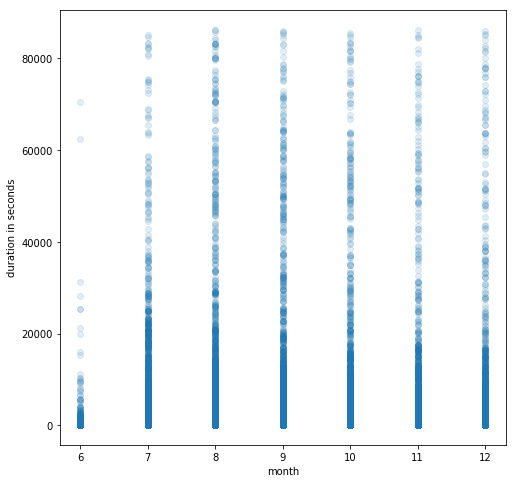

```python
plt.figure(figsize=[8, 8])
plt.scatter(data = df, x = 'start_month', y = 'duration_sec', alpha = 1/8)
plt.xlabel('month')
plt.ylabel('duration in seconds');
```

link used: https://en.wikipedia.org/wiki/Ford_GoBike

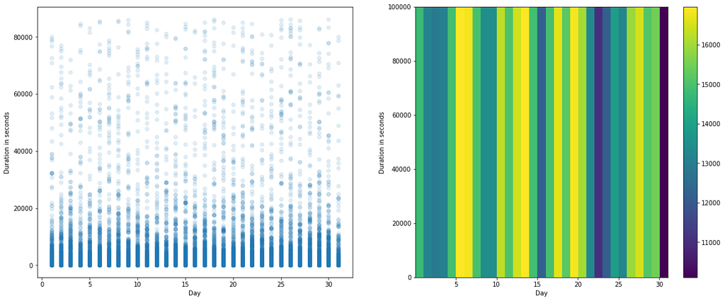

```python
plt.figure(figsize = [20, 8])

#Scatterplot
plt.subplot(1, 2, 1)
plt.scatter(data = df, x = 'start_day', y = 'duration_sec', alpha = 1/8)
plt.xlabel('Day')
plt.ylabel('Duration in seconds');

#Heatmap
plt.subplot(1, 2, 2)
bins_x = np.arange(0.05, 31+1, 1)
bins_y = np.arange(-0.05, 100000+1, 100000)
plt.hist2d(data = df, x = 'start_day', y = 'duration_sec',
           bins = [bins_x, bins_y])
plt.xlabel('Day')
plt.ylabel('Duration in seconds')
plt.colorbar();
```

Since it's kinda hard to see on the scatterplot I decided to add a heatmap. The lighter the bar, the more trips were taken that day.

### Did you observe any interesting relationships between the other features (not the main feature(s) of interest)?

Not really.

## Multivariate Exploration

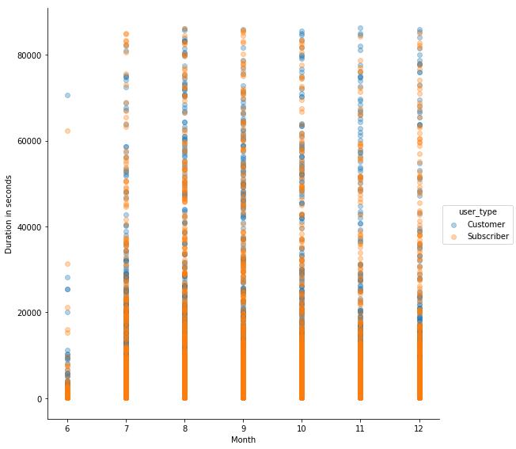

```python
month = sb.FacetGrid(data = df, hue = 'user_type', size = 8)
month.map(plt.scatter, 'start_month','duration_sec', alpha = 1/3)
month.add_legend()
plt.xlabel('Month')
plt.ylabel('Duration in seconds');
```

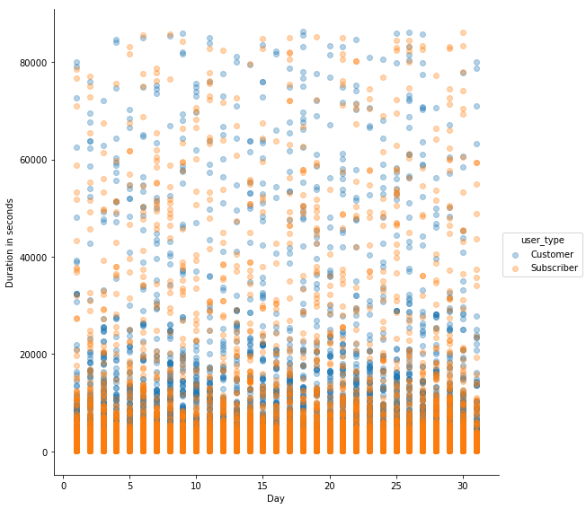

```python
day = sb.FacetGrid(data = df, hue = 'user_type', size = 8)
day.map(plt.scatter, 'start_day','duration_sec', alpha = 1/3)
day.add_legend()
plt.xlabel('Day')
plt.ylabel('Duration in seconds');
```

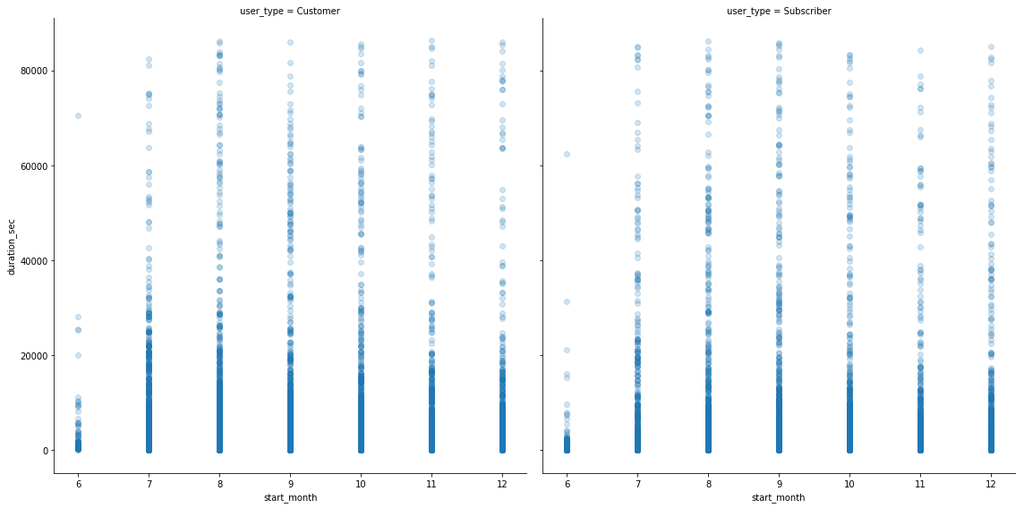

```python
m = sb.FacetGrid(data = df, col = 'user_type', size = 8,
                     col_wrap = 2)
m.map(sb.regplot, 'start_month', 'duration_sec', y_jitter = 0.04, fit_reg = False,
        scatter_kws = {'alpha' : 1/5});
```

If you put the scatterplots beside each other like this it's kinda hard to see which user type is more common on a monthly level since the most rides are taken for a short duration.

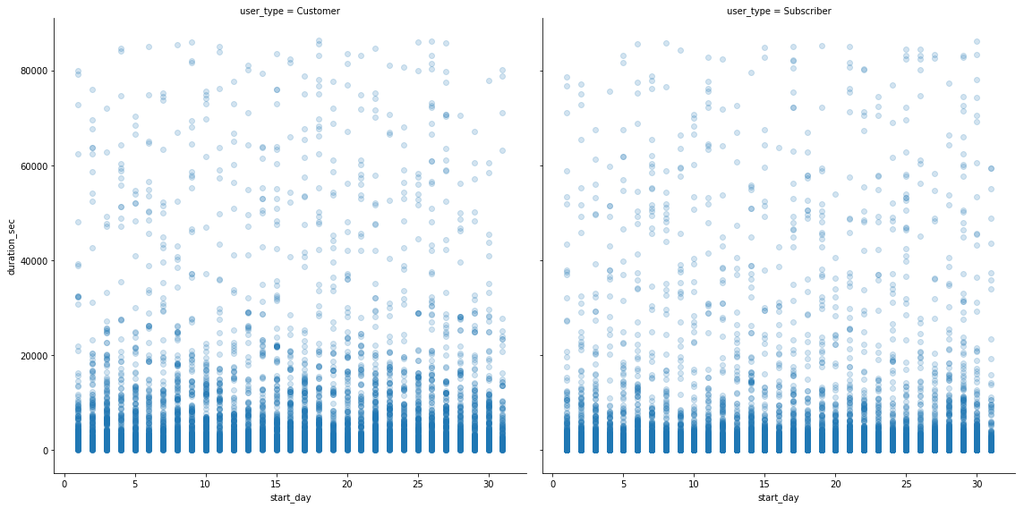

```python
g = sb.FacetGrid(data = df, col = 'user_type', size = 8,
                     col_wrap = 2)
g.map(sb.regplot, 'start_day', 'duration_sec', y_jitter = 0.04, fit_reg = False,
        scatter_kws = {'alpha' : 1/5});
```

If you put the scatterplots beside each other like this it's kinda hard to see which user type is more common on a daily level since the most rides are taken for a short duration.

### Talk about some of the relationships you observed in this part of the investigation. Were there features that strengthened each other in terms of looking at your feature(s) of interest?

I found out that there are way more subscribers than regular customers. I also found out that there is not really a behavioral diffence between subscribers and customers.

### Were there any interesting or surprising interactions between features?

Not really. Both of the user types behave very similar.